# Introduction to R

MA and PhD Course (University of Zurich)

Marco Steenbergen & Christian Rubba

September 11, 2015

[html Version](http://christianrubba.com/courses/RIntro/html/RIntro.html) [PDF Version](http://christianrubba.com/courses/RIntro/pdf/RIntro.pdf) This is an R Markdown document. Markdown is a simple formatting syntax for authoring HTML, PDF, and MS Word documents. For more details on using R Markdown see http://rmarkdown.rstudio.com.

# Start

## Wieso R?

- kostenlos
- für alle gängigen Betriebssysteme erhältlich
- in Umfang und Qualität besser als viele kommerzielle Statistikprogramme.
- Standard in vielen wissenschaftlichen Communities, u.a. in Politikwissenschaft
- grosse Community (=Hilfe)
- Vielseitige Programmiersprache

## Paketinstallation

```r
pkgs <- c("readr", "haven", "dplyr", "ggplot2", "magrittr", "devtools")
install.packages(pkgs)
```

- Mittels `update_packages(ask = FALSE)` können die Pakete zu einem späteren Zeitpunkt aktualisiert werden.

## Download the data

```r
setwd("your working directory")
data_src <- list(
  "http://christianrubba/lehre/data/1.csv"

)

lapply(data_scr, download.file)
```

# Tidy Data

- Beobachtungen sind in den Reihen
- Variablen sind in den Spalten
- Alle Informationen sind in einem Datensatz enthalten

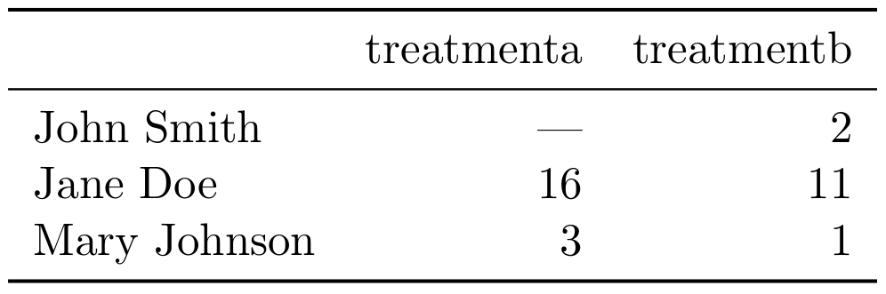

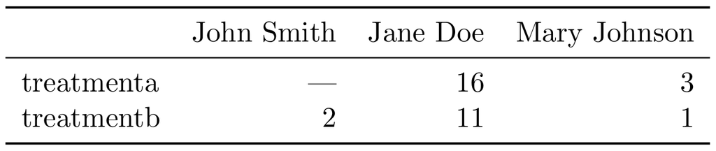

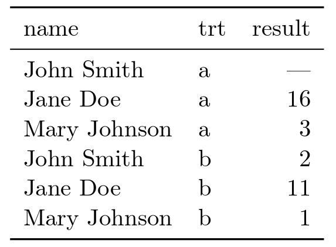